# ipl

```python
%matplotlib inline
import pandas as pd
import matplotlib.pyplot as plt
import numpy as np
import seaborn as sns
```

```python
match = pd.read_csv('https://query.data.world/s/m54dq57xejyyson5ouzec2vuha4e5i',
                parse_dates= True,index_col='match_date')
```

```python
match.head(900)
```

| match_date | Match_SK | match_id | Team1 | Team2 | Season_Year | Venue_Name | City_Name | Country_Name | Toss_Winner | match_winner | Toss_Name | Win_Type | Outcome_Type | ManOfMach | Win_Margin | Country_id |
| --- | --- | --- | --- | --- | --- | --- | --- | --- | --- | --- | --- | --- | --- | --- | --- | --- |
| 2008-04-18 | 0 | 335987 | Royal Challengers Bangalore | Kolkata Knight Riders | 2008 | M Chinnaswamy Stadium | Bangalore | India | Royal Challengers Bangalore | Kolkata Knight Riders | field | runs | Result | BB McCullum | 140.0 | 1 |
| 2008-04-19 | 1 | 335988 | Kings XI Punjab | Chennai Super Kings | 2008 | Punjab Cricket Association Stadium, Mohali | Chandigarh | India | Chennai Super Kings | Chennai Super Kings | bat | runs | Result | MEK Hussey | 33.0 | 1 |
| 2008-04-19 | 2 | 335989 | Delhi Daredevils | Rajasthan Royals | 2008 | Feroz Shah Kotla | Delhi | India | Rajasthan Royals | Delhi Daredevils | bat | wickets | Result | MF Maharoof | 9.0 | 1 |
| 2008-04-20 | 3 | 335990 | Mumbai Indians | Royal Challengers Bangalore | 2008 | Wankhede Stadium | Mumbai | India | Mumbai Indians | Royal Challengers Bangalore | bat | wickets | Result | MV Boucher | 5.0 | 1 |
| 2008-04-20 | 4 | 335991 | Kolkata Knight Riders | Deccan Chargers | 2008 | Eden Gardens | Kolkata | India | Deccan Chargers | Kolkata Knight Riders | bat | wickets | Result | DJ Hussey | 5.0 | 1 |
| 2008-04-21 | 5 | 335992 | Rajasthan Royals | Kings XI Punjab | 2008 | Sawai Mansingh Stadium | Jaipur | India | Kings XI Punjab | Rajasthan Royals | bat | wickets | Result | SR Watson | 6.0 | 1 |
| 2008-04-22 | 6 | 335993 | Deccan Chargers | Delhi Daredevils | 2008 | Rajiv Gandhi International Stadium, Uppal | Hyderabad | India | Deccan Chargers | Delhi Daredevils | bat | wickets | Result | V Sehwag | 9.0 | 1 |
| 2008-04-23 | 7 | 335994 | Chennai Super Kings | Mumbai Indians | 2008 | MA Chidambaram Stadium, Chepauk | Chennai | India | Mumbai Indians | Chennai Super Kings | field | runs | Result | ML Hayden | 6.0 | 1 |
| 2008-04-24 | 8 | 335995 | Deccan Chargers | Rajasthan Royals | 2008 | Rajiv Gandhi International Stadium, Uppal | Hyderabad | India | Rajasthan Royals | Rajasthan Royals | field | wickets | Result | YK Pathan | 3.0 | 1 |
| 2008-04-25 | 9 | 335996 | Kings XI Punjab | Mumbai Indians | 2008 | Punjab Cricket Association Stadium, Mohali | Chandigarh | India | Mumbai Indians | Kings XI Punjab | field | runs | Result | KC Sangakkara | 66.0 | 1 |
| 2008-04-26 | 10 | 335997 | Royal Challengers Bangalore | Rajasthan Royals | 2008 | M Chinnaswamy Stadium | Bangalore | India | Rajasthan Royals | Rajasthan Royals | field | wickets | Result | SR Watson | 7.0 | 1 |
| 2008-04-26 | 11 | 335998 | Chennai Super Kings | Kolkata Knight Riders | 2008 | MA Chidambaram Stadium, Chepauk | Chennai | India | Kolkata Knight Riders | Chennai Super Kings | bat | wickets | Result | JDP Oram | 9.0 | 1 |
| 2008-04-27 | 12 | 335999 | Mumbai Indians | Deccan Chargers | 2008 | Dr DY Patil Sports Academy | Mumbai | India | Deccan Chargers | Deccan Chargers | field | wickets | Result | AC Gilchrist | 10.0 | 1 |
| 2008-04-27 | 13 | 336000 | Kings XI Punjab | Delhi Daredevils | 2008 | Punjab Cricket Association Stadium, Mohali | Chandigarh | India | Delhi Daredevils | Kings XI Punjab | bat | wickets | Result | SM Katich | 4.0 | 1 |
| 2008-04-28 | 14 | 336001 | Royal Challengers Bangalore | Chennai Super Kings | 2008 | M Chinnaswamy Stadium | Bangalore | India | Chennai Super Kings | Chennai Super Kings | bat | runs | Result | MS Dhoni | 13.0 | 1 |
| 2008-04-29 | 15 | 336002 | Kolkata Knight Riders | Mumbai Indians | 2008 | Eden Gardens | Kolkata | India | Kolkata Knight Riders | Mumbai Indians | bat | wickets | Result | ST Jayasuriya | 7.0 | 1 |
| 2008-04-30 | 16 | 336003 | Delhi Daredevils | Royal Challengers Bangalore | 2008 | Feroz Shah Kotla | Delhi | India | Royal Challengers Bangalore | Delhi Daredevils | field | runs | Result | GD McGrath | 10.0 | 1 |
| 2008-05-01 | 17 | 336004 | Deccan Chargers | Kings XI Punjab | 2008 | Rajiv Gandhi International Stadium, Uppal | Hyderabad | India | Kings XI Punjab | Kings XI Punjab | field | wickets | Result | SE Marsh | 7.0 | 1 |
| 2008-05-01 | 18 | 336005 | Rajasthan Royals | Kolkata Knight Riders | 2008 | Sawai Mansingh Stadium | Jaipur | India | Rajasthan Royals | Rajasthan Royals | bat | runs | Result | SA Asnodkar | 45.0 | 1 |
| 2008-05-02 | 19 | 336006 | Chennai Super Kings | Delhi Daredevils | 2008 | MA Chidambaram Stadium, Chepauk | Chennai | India | Chennai Super Kings | Delhi Daredevils | bat | wickets | Result | V Sehwag | 8.0 | 1 |
| 2008-05-25 | 20 | 336007 | Deccan Chargers | Royal Challengers Bangalore | 2008 | Rajiv Gandhi International Stadium, Uppal | Hyderabad | India | Deccan Chargers | Royal Challengers Bangalore | bat | wickets | Result | R Vinay Kumar | 5.0 | 1 |
| 2008-05-03 | 21 | 336008 | Kings XI Punjab | Kolkata Knight Riders | 2008 | Punjab Cricket Association Stadium, Mohali | Chandigarh | India | Kings XI Punjab | Kings XI Punjab | bat | runs | Result | IK Pathan | 9.0 | 1 |
| 2008-05-04 | 22 | 336009 | Mumbai Indians | Delhi Daredevils | 2008 | Dr DY Patil Sports Academy | Mumbai | India | Delhi Daredevils | Mumbai Indians | field | runs | Result | SM Pollock | 29.0 | 1 |
| 2008-05-04 | 23 | 336010 | Rajasthan Royals | Chennai Super Kings | 2008 | Sawai Mansingh Stadium | Jaipur | India | Chennai Super Kings | Rajasthan Royals | bat | wickets | Result | Sohail Tanvir | 8.0 | 1 |
| 2008-05-05 | 24 | 336011 | Royal Challengers Bangalore | Kings XI Punjab | 2008 | M Chinnaswamy Stadium | Bangalore | India | Kings XI Punjab | Kings XI Punjab | field | wickets | Result | S Sreesanth | 6.0 | 1 |
| 2008-05-06 | 25 | 336012 | Chennai Super Kings | Deccan Chargers | 2008 | MA Chidambaram Stadium, Chepauk | Chennai | India | Deccan Chargers | Deccan Chargers | field | wickets | Result | AC Gilchrist | 7.0 | 1 |
| 2008-05-07 | 26 | 336013 | Mumbai Indians | Rajasthan Royals | 2008 | Dr DY Patil Sports Academy | Mumbai | India | Mumbai Indians | Mumbai Indians | field | wickets | Result | A Nehra | 7.0 | 1 |
| 2008-05-08 | 27 | 336014 | Delhi Daredevils | Chennai Super Kings | 2008 | Feroz Shah Kotla | Delhi | India | Chennai Super Kings | Chennai Super Kings | field | wickets | Result | MS Dhoni | 4.0 | 1 |
| 2008-05-08 | 28 | 336015 | Kolkata Knight Riders | Royal Challengers Bangalore | 2008 | Eden Gardens | Kolkata | India | Kolkata Knight Riders | Kolkata Knight Riders | bat | runs | Result | SC Ganguly | 5.0 | 1 |
| 2008-05-09 | 29 | 336016 | Rajasthan Royals | Deccan Chargers | 2008 | Sawai Mansingh Stadium | Jaipur | India | Rajasthan Royals | Rajasthan Royals | field | wickets | Result | YK Pathan | 8.0 | 1 |
| ... | ... | ... | ... | ... | ... | ... | ... | ... | ... | ... | ... | ... | ... | ... | ... | ... |
| 2017-04-27 | 607 | 1082621 | Royal Challengers Bangalore | Gujarat Lions | 2017 | M Chinnaswamy Stadium | Bengaluru | India | Gujarat Lions | Gujarat Lions | Field | wickets | Result | AJ Tye | 7.0 | 1 |
| 2017-04-28 | 608 | 1082622 | Kolkata Knight Riders | Delhi Daredevils | 2017 | Eden Gardens | Kolkata | India | Kolkata Knight Riders | Kolkata Knight Riders | Field | wickets | Result | G Gambhir | 7.0 | 1 |
| 2017-04-28 | 609 | 1082623 | Kings XI Punjab | Sunrisers Hyderabad | 2017 | Punjab Cricket Association IS Bindra Stadium M... | Mohali | India | Kings XI Punjab | Sunrisers Hyderabad | Field | runs | Result | Rashid Khan | 26.0 | 1 |
| 2017-04-29 | 610 | 1082624 | Rising Pune Supergiants | Royal Challengers Bangalore | 2017 | Maharashtra Cricket Association Stadium | Pune | India | Royal Challengers Bangalore | Rising Pune Supergiants | Field | runs | Result | LH Ferguson | 61.0 | 1 |
| 2017-04-29 | 611 | 1082625 | Gujarat Lions | Mumbai Indians | 2017 | Saurashtra Cricket Association Stadium | Rajkot | India | Gujarat Lions | tied | Bat | NaN | tied | KH Pandya | 0.0 | 1 |
| 2017-04-30 | 612 | 1082626 | Kings XI Punjab | Delhi Daredevils | 2017 | Punjab Cricket Association IS Bindra Stadium M... | Mohali | India | Kings XI Punjab | Kings XI Punjab | Field | wickets | Result | Sandeep Sharma | 10.0 | 1 |
| 2017-04-30 | 613 | 1082627 | Sunrisers Hyderabad | Kolkata Knight Riders | 2017 | Rajiv Gandhi International Stadium Uppal | Hyderabad (Deccan) | India | Kolkata Knight Riders | Sunrisers Hyderabad | Field | runs | Result | DA Warner | 48.0 | 1 |
| 2017-05-01 | 614 | 1082628 | Mumbai Indians | Royal Challengers Bangalore | 2017 | Wankhede Stadium | Mumbai | India | Royal Challengers Bangalore | Mumbai Indians | Bat | wickets | Result | RG Sharma | 5.0 | 1 |
| 2017-05-01 | 615 | 1082629 | Rising Pune Supergiants | Gujarat Lions | 2017 | Maharashtra Cricket Association Stadium | Pune | India | Rising Pune Supergiants | Rising Pune Supergiants | Field | wickets | Result | BA Stokes | 5.0 | 1 |
| 2017-05-02 | 616 | 1082630 | Delhi Daredevils | Sunrisers Hyderabad | 2017 | Feroz Shah Kotla | Delhi | India | Delhi Daredevils | Delhi Daredevils | Field | wickets | Result | Mohammed Shami | 6.0 | 1 |
| 2017-05-03 | 617 | 1082631 | Kolkata Knight Riders | Rising Pune Supergiants | 2017 | Eden Gardens | Kolkata | India | Rising Pune Supergiants | Rising Pune Supergiants | Field | wickets | Result | RA Tripathi | 4.0 | 1 |
| 2017-05-04 | 618 | 1082632 | Delhi Daredevils | Gujarat Lions | 2017 | Feroz Shah Kotla | Delhi | India | Delhi Daredevils | Delhi Daredevils | Field | wickets | Result | RR Pant | 7.0 | 1 |
| 2017-05-05 | 619 | 1082633 | Royal Challengers Bangalore | Kings XI Punjab | 2017 | M Chinnaswamy Stadium | Bengaluru | India | Royal Challengers Bangalore | Kings XI Punjab | Field | runs | Result | Sandeep Sharma | 19.0 | 1 |
| 2017-05-06 | 620 | 1082634 | Sunrisers Hyderabad | Rising Pune Supergiants | 2017 | Rajiv Gandhi International Stadium Uppal | Hyderabad (Deccan) | India | Sunrisers Hyderabad | Rising Pune Supergiants | Field | runs | Result | JD Unadkat | 12.0 | 1 |
| 2017-05-06 | 621 | 1082635 | Delhi Daredevils | Mumbai Indians | 2017 | Feroz Shah Kotla | Delhi | India | Delhi Daredevils | Mumbai Indians | Field | runs | Result | LMP Simmons | 146.0 | 1 |
| 2017-05-07 | 622 | 1082636 | Royal Challengers Bangalore | Kolkata Knight Riders | 2017 | M Chinnaswamy Stadium | Bengaluru | India | Kolkata Knight Riders | Kolkata Knight Riders | Field | wickets | Result | SP Narine | 6.0 | 1 |
| 2017-05-07 | 623 | 1082637 | Kings XI Punjab | Gujarat Lions | 2017 | Punjab Cricket Association IS Bindra Stadium M... | Mohali | India | Gujarat Lions | Gujarat Lions | Field | wickets | Result | DR Smith | 6.0 | 1 |
| 2017-05-08 | 624 | 1082638 | Sunrisers Hyderabad | Mumbai Indians | 2017 | Rajiv Gandhi International Stadium Uppal | Hyderabad (Deccan) | India | Mumbai Indians | Sunrisers Hyderabad | Bat | wickets | Result | S Dhawan | 7.0 | 1 |
| 2017-05-09 | 625 | 1082639 | Kings XI Punjab | Kolkata Knight Riders | 2017 | Punjab Cricket Association IS Bindra Stadium M... | Mohali | India | Kolkata Knight Riders | Kings XI Punjab | Field | runs | Result | MM Sharma | 14.0 | 1 |
| 2017-05-10 | 626 | 1082640 | Gujarat Lions | Delhi Daredevils | 2017 | Green Park | Kanpur | India | Delhi Daredevils | Delhi Daredevils | Field | wickets | Result | SS Iyer | 2.0 | 1 |
| 2017-05-11 | 627 | 1082641 | Mumbai Indians | Kings XI Punjab | 2017 | Wankhede Stadium | Mumbai | India | Mumbai Indians | Kings XI Punjab | Field | runs | Result | WP Saha | 7.0 | 1 |
| 2017-05-12 | 628 | 1082642 | Delhi Daredevils | Rising Pune Supergiants | 2017 | Feroz Shah Kotla | Delhi | India | Delhi Daredevils | Delhi Daredevils | Bat | runs | Result | KK Nair | 7.0 | 1 |
| 2017-05-13 | 629 | 1082643 | Gujarat Lions | Sunrisers Hyderabad | 2017 | Green Park | Kanpur | India | Sunrisers Hyderabad | Sunrisers Hyderabad | Field | wickets | Result | Mohammed Siraj | 8.0 | 1 |
| 2017-05-13 | 630 | 1082644 | Kolkata Knight Riders | Mumbai Indians | 2017 | Eden Gardens | Kolkata | India | Kolkata Knight Riders | Mumbai Indians | Field | runs | Result | AT Rayudu | 9.0 | 1 |
| 2017-05-14 | 631 | 1082645 | Rising Pune Supergiants | Kings XI Punjab | 2017 | Maharashtra Cricket Association Stadium | Pune | India | Rising Pune Supergiants | Rising Pune Supergiants | Field | wickets | Result | JD Unadkat | 9.0 | 1 |
| 2017-05-14 | 632 | 1082646 | Delhi Daredevils | Royal Challengers Bangalore | 2017 | Feroz Shah Kotla | Delhi | India | Royal Challengers Bangalore | Royal Challengers Bangalore | Bat | runs | Result | HV Patel | 10.0 | 1 |
| 2017-05-16 | 633 | 1082647 | Mumbai Indians | Rising Pune Supergiants | 2017 | Wankhede Stadium | Mumbai | India | Mumbai Indians | Rising Pune Supergiants | Field | runs | Result | Wasington Sundar | 20.0 | 1 |
| 2017-05-17 | 634 | 1082648 | Sunrisers Hyderabad | Kolkata Knight Riders | 2017 | M Chinnaswamy Stadium | Bengaluru | India | Kolkata Knight Riders | Kolkata Knight Riders | Field | wickets | Result | NM Coulter-Nile | 7.0 | 1 |
| 2017-05-19 | 635 | 1082649 | Mumbai Indians | Kolkata Knight Riders | 2017 | M Chinnaswamy Stadium | Bengaluru | India | Mumbai Indians | Mumbai Indians | Field | wickets | Result | KV Sharma | 6.0 | 1 |
| 2017-05-21 | 636 | 1082650 | Mumbai Indians | Rising Pune Supergiants | 2017 | Rajiv Gandhi International Stadium Uppal | Hyderabad (Deccan) | India | Mumbai Indians | Mumbai Indians | Bat | run | Result | KH Pandya | 1.0 | 1 |

637 rows × 16 columns

```python
n_city=match['City_Name']
is_delhi= n_city.str.contains('Delhi')
```

```python
is_delhi[:5]
```

```
match_date
2008-04-18    False
2008-04-19    False
2008-04-19     True
2008-04-20    False
2008-04-20    False
Name: City_Name, dtype: bool
```

```python
is_delhi=is_delhi.astype(float)
```

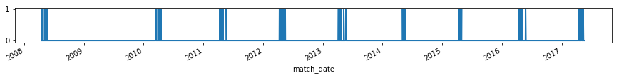

```python
is_delhi.plot(figsize=(15,1))
```

conclusion: The match dates when matches took place in Delhi is shown as above. It is observed that the maximum no. of match in Delhi took place in the year 2012.

```python
is_delhi.astype(float).resample('M').apply(np.mean)
```

```
match_date
2008-04-30    0.117647
2008-05-31    0.100000
2008-06-30    0.000000
2008-07-31         NaN
2008-08-31         NaN
2008-09-30         NaN
2008-10-31         NaN
2008-11-30         NaN
2008-12-31         NaN
2009-01-31         NaN
2009-02-28         NaN
2009-03-31         NaN
2009-04-30    0.000000
2009-05-31    0.000000
2009-06-30         NaN
2009-07-31         NaN
2009-08-31         NaN
2009-09-30         NaN
2009-10-31         NaN
2009-11-30         NaN
2009-12-31         NaN
2010-01-31         NaN
2010-02-28         NaN
2010-03-31    0.137931
2010-04-30    0.096774
2010-05-31         NaN
2010-06-30         NaN
2010-07-31         NaN
2010-08-31         NaN
2010-09-30         NaN
                ...
2014-12-31         NaN
2015-01-31         NaN
2015-02-28         NaN
2015-03-31         NaN
2015-04-30    0.137931
2015-05-31    0.033333
2015-06-30         NaN
2015-07-31         NaN
```

[output cut: 8 more lines]

```
2016-04-30    0.148148
2016-05-31    0.090909
2016-06-30         NaN
2016-07-31         NaN
2016-08-31         NaN
2016-09-30         NaN
2016-10-31         NaN
2016-11-30         NaN
2016-12-31         NaN
2017-01-31         NaN
2017-02-28         NaN
2017-03-31         NaN
2017-04-30    0.054054
2017-05-31    0.217391
Freq: M, Name: City_Name, Length: 110, dtype: float64
```

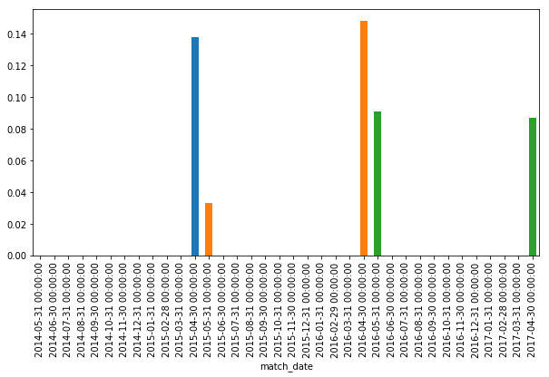

```python
is_delhi.loc['2014-05-21':'2017-04-21'].astype(float).resample('M').apply(np.mean).plot(kind='bar',figsize=(10,5))
```

Conclusion: The mean matches that took place in between 2014-2017 in Delhi can be shown by the graph. You can change the range of the year as per your requirement.

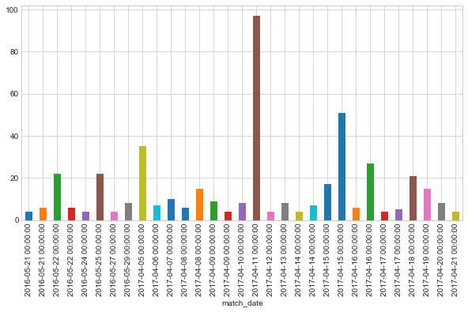

```python
match.loc['2016-05-21':'2017-04-21'].Win_Margin.plot(kind='bar',x='match_date', y='Win_Margin',figsize=(10,5))
```

```python
both_teams=match[['Team1','Team2','match_winner','Win_Margin']].copy()
```

```python
both_teams.sort_values(by='Win_Margin', ascending=False, inplace=True)
```

```python
both_teams.head()
```

| match_date | Team1 | Team2 | match_winner | Win_Margin |
| --- | --- | --- | --- | --- |
| 2017-05-06 | Delhi Daredevils | Mumbai Indians | Mumbai Indians | 146.0 |
| 2016-05-14 | Royal Challengers Bangalore | Gujarat Lions | Royal Challengers Bangalore | 144.0 |
| 2008-04-18 | Royal Challengers Bangalore | Kolkata Knight Riders | Kolkata Knight Riders | 140.0 |
| 2015-05-06 | Royal Challengers Bangalore | Kings XI Punjab | Royal Challengers Bangalore | 138.0 |
| 2013-04-23 | Royal Challengers Bangalore | Pune Warriors | Royal Challengers Bangalore | 130.0 |

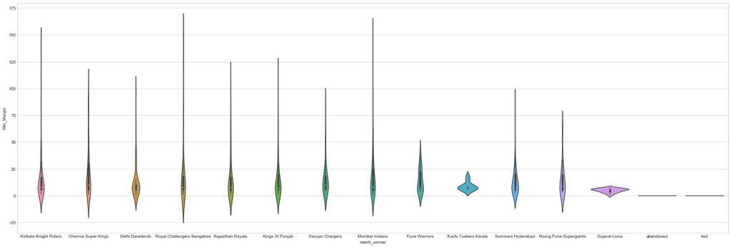

```python
# Set theme
sns.set_style('whitegrid')

# Violin plot
plt.figure(figsize=(30,10))
sns.violinplot(x='match_winner', y='Win_Margin', data=match)
```

[output not shown]

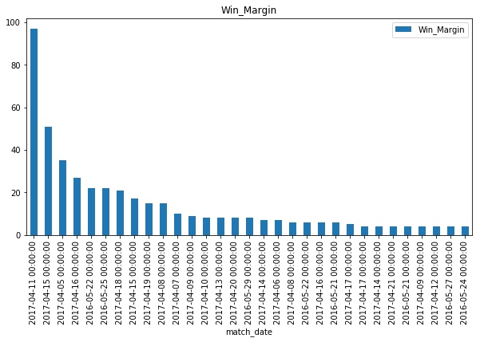

```python
both_teams.loc['2016-05-21':'2017-04-21'].plot(kind='bar',subplots=True,figsize=(10,5))
```

Conclusion: This graph shows the max run margin by the date of match. It can be concluded that the max run margin win was in the year 2017-04-11. The range of the year can be changed according to your needs.

```python
match.loc['2016-05-21':'2017-04-21']
```

| match_date | Match_SK | match_id | Team1 | Team2 | Season_Year | Venue_Name | City_Name | Country_Name | Toss_Winner | match_winner | Toss_Name | Win_Type | Outcome_Type | ManOfMach | Win_Margin | Country_id |
| --- | --- | --- | --- | --- | --- | --- | --- | --- | --- | --- | --- | --- | --- | --- | --- | --- |
| 2016-05-21 | 569 | 981010 | Rising Pune Supergiants | Kings XI Punjab | 2016 | Dr. Y.S. Rajasekhara Reddy ACA-VDCA Cricket St... | Visakhapatnam | India | Kings XI Punjab | Rising Pune Supergiants | bat | wickets | Result | MS Dhoni | 4.0 | 1 |
| 2016-05-21 | 570 | 981012 | Gujarat Lions | Mumbai Indians | 2016 | Green Park | Kanpur | India | Gujarat Lions | Gujarat Lions | field | wickets | Result | SK Raina | 6.0 | 1 |
| 2016-05-22 | 571 | 981014 | Kolkata Knight Riders | Sunrisers Hyderabad | 2016 | Eden Gardens | Kolkata | India | Sunrisers Hyderabad | Kolkata Knight Riders | field | runs | Result | YK Pathan | 22.0 | 1 |
| 2016-05-22 | 572 | 981016 | Delhi Daredevils | Royal Challengers Bangalore | 2016 | Shaheed Veer Narayan Singh International Stadium | Raipur | India | Royal Challengers Bangalore | Royal Challengers Bangalore | field | wickets | Result | V Kohli | 6.0 | 1 |
| 2016-05-24 | 573 | 981018 | Gujarat Lions | Royal Challengers Bangalore | 2016 | M Chinnaswamy Stadium | Bangalore | India | Royal Challengers Bangalore | Royal Challengers Bangalore | field | wickets | Result | AB de Villiers | 4.0 | 1 |
| 2016-05-25 | 574 | 981020 | Sunrisers Hyderabad | Kolkata Knight Riders | 2016 | Feroz Shah Kotla | Delhi | India | Kolkata Knight Riders | Sunrisers Hyderabad | field | runs | Result | MC Henriques | 22.0 | 1 |
| 2016-05-27 | 575 | 981022 | Gujarat Lions | Sunrisers Hyderabad | 2016 | Feroz Shah Kotla | Delhi | India | Sunrisers Hyderabad | Sunrisers Hyderabad | field | wickets | Result | DA Warner | 4.0 | 1 |
| 2016-05-29 | 576 | 981024 | Royal Challengers Bangalore | Sunrisers Hyderabad | 2016 | M Chinnaswamy Stadium | Bangalore | India | Sunrisers Hyderabad | Sunrisers Hyderabad | bat | runs | Result | BCJ Cutting | 8.0 | 1 |
| 2017-04-05 | 577 | 1082591 | Sunrisers Hyderabad | Royal Challengers Bangalore | 2017 | Rajiv Gandhi International Stadium Uppal | Hyderabad (Deccan) | India | Royal Challengers Bangalore | Sunrisers Hyderabad | Field | runs | Result | Yuvraj Singh | 35.0 | 1 |
| 2017-04-06 | 578 | 1082592 | Rising Pune Supergiants | Mumbai Indians | 2017 | Maharashtra Cricket Association Stadium | Pune | India | Rising Pune Supergiant | Rising Pune Supergiants | Field | wickets | Result | SPD Smith | 7.0 | 1 |
| 2017-04-07 | 579 | 1082593 | Gujarat Lions | Kolkata Knight Riders | 2017 | Saurashtra Cricket Association Stadium | Rajkot | India | Kolkata Knight Riders | Kolkata Knight Riders | Field | wickets | Result | CA Lynn | 10.0 | 1 |
| 2017-04-08 | 580 | 1082594 | Kings XI Punjab | Rising Pune Supergiants | 2017 | Holkar Cricket Stadium | Indore | India | Kings XI Punjab | Kings XI Punjab | Field | wickets | Result | GJ Maxwell | 6.0 | 1 |
| 2017-04-08 | 581 | 1082595 | Royal Challengers Bangalore | Delhi Daredevils | 2017 | M Chinnaswamy Stadium | Bengaluru | India | Royal Challengers Bangalore | Royal Challengers Bangalore | Bat | runs | Result | KM Jadhav | 15.0 | 1 |
| 2017-04-09 | 582 | 1082596 | Sunrisers Hyderabad | Gujarat Lions | 2017 | Rajiv Gandhi International Stadium Uppal | Hyderabad (Deccan) | India | Sunrisers Hyderabad | Sunrisers Hyderabad | Field | wickets | Result | Rashid Khan | 9.0 | 1 |
| 2017-04-09 | 583 | 1082597 | Mumbai Indians | Kolkata Knight Riders | 2017 | Wankhede Stadium | Mumbai | India | Mumbai Indians | Mumbai Indians | Field | wickets | Result | N Rana | 4.0 | 1 |
| 2017-04-10 | 584 | 1082598 | Kings XI Punjab | Royal Challengers Bangalore | 2017 | Holkar Cricket Stadium | Indore | India | Royal Challengers Bangalore | Kings XI Punjab | Bat | wickets | Result | AR Patel | 8.0 | 1 |
| 2017-04-11 | 585 | 1082599 | Rising Pune Supergiants | Delhi Daredevils | 2017 | Maharashtra Cricket Association Stadium | Pune | India | Rising Pune Supergiants | Delhi Daredevils | Field | runs | Result | SV Samson | 97.0 | 1 |
| 2017-04-12 | 586 | 1082600 | Mumbai Indians | Sunrisers Hyderabad | 2017 | Wankhede Stadium | Mumbai | India | Mumbai Indians | Mumbai Indians | Field | wickets | Result | JJ Bumrah | 4.0 | 1 |
| 2017-04-13 | 587 | 1082601 | Kolkata Knight Riders | Kings XI Punjab | 2017 | Eden Gardens | Kolkata | India | Kolkata Knight Riders | Kolkata Knight Riders | Field | wickets | Result | Narine | 8.0 | 1 |
| 2017-04-14 | 588 | 1082602 | Royal Challengers Bangalore | Mumbai Indians | 2017 | M Chinnaswamy Stadium | Bengaluru | India | Mumbai Indians | Mumbai Indians | Field | wickets | Result | KA Pollard | 4.0 | 1 |
| 2017-04-14 | 589 | 1082603 | Gujarat Lions | Rising Pune Supergiants | 2017 | Saurashtra Cricket Association Stadium | Rajkot | India | Gujarat Lions | Gujarat Lions | Field | wickets | Result | AJ Tye | 7.0 | 1 |
| 2017-04-15 | 590 | 1082604 | Kolkata Knight Riders | Sunrisers Hyderabad | 2017 | Eden Gardens | Kolkata | India | Sunrisers Hyderabad | Kolkata Knight Riders | Field | runs | Result | RV Uthappa | 17.0 | 1 |
| 2017-04-15 | 591 | 1082605 | Delhi Daredevils | Kings XI Punjab | 2017 | Feroz Shah Kotla | Delhi | India | Delhi Daredevils | Delhi Daredevils | Bat | runs | Result | CJ Anderson | 51.0 | 1 |
| 2017-04-16 | 592 | 1082606 | Mumbai Indians | Gujarat Lions | 2017 | Wankhede Stadium | Mumbai | India | Mumbai Indians | Mumbai Indians | Field | wickets | Result | N Rana | 6.0 | 1 |
| 2017-04-16 | 593 | 1082607 | Royal Challengers Bangalore | Rising Pune Supergiants | 2017 | M Chinnaswamy Stadium | Bengaluru | India | Royal Challengers Bangalore | Rising Pune Supergiants | Field | runs | Result | BA Stokes | 27.0 | 1 |
| 2017-04-17 | 594 | 1082608 | Delhi Daredevils | Kolkata Knight Riders | 2017 | Feroz Shah Kotla | Delhi | India | Delhi Daredevils | Kolkata Knight Riders | Bat | wickets | Result | NM Coulter-Nile | 4.0 | 1 |
| 2017-04-17 | 595 | 1082609 | Sunrisers Hyderabad | Kings XI Punjab | 2017 | Rajiv Gandhi International Stadium Uppal | Hyderabad (Deccan) | India | Kings XI Punjab | Sunrisers Hyderabad | Field | runs | Result | B Kumar | 5.0 | 1 |
| 2017-04-18 | 596 | 1082610 | Gujarat Lions | Royal Challengers Bangalore | 2017 | Saurashtra Cricket Association Stadium | Rajkot | India | Gujarat Lions | Royal Challengers Bangalore | Field | runs | Result | CH Gayle | 21.0 | 1 |
| 2017-04-19 | 597 | 1082611 | Sunrisers Hyderabad | Delhi Daredevils | 2017 | Rajiv Gandhi International Stadium Uppal | Hyderabad (Deccan) | India | Sunrisers Hyderabad | Sunrisers Hyderabad | Bat | runs | Result | KS Williamson | 15.0 | 1 |
| 2017-04-20 | 598 | 1082612 | Kings XI Punjab | Mumbai Indians | 2017 | Holkar Cricket Stadium | Indore | India | Mumbai Indians | Mumbai Indians | Field | wickets | Result | JC Buttler | 8.0 | 1 |
| 2017-04-21 | 599 | 1082613 | Kolkata Knight Riders | Gujarat Lions | 2017 | Eden Gardens | Kolkata | India | Gujarat Lions | Gujarat Lions | Field | wickets | Result | SK Raina | 4.0 | 1 |

```python
match[['Team1','Team2','match_id','match_winner','Win_Margin']].loc['2016-05-21':'2017-04-21']
```

| match_date | Team1 | Team2 | match_id | match_winner | Win_Margin |
| --- | --- | --- | --- | --- | --- |
| 2016-05-21 | Rising Pune Supergiants | Kings XI Punjab | 981010 | Rising Pune Supergiants | 4.0 |
| 2016-05-21 | Gujarat Lions | Mumbai Indians | 981012 | Gujarat Lions | 6.0 |
| 2016-05-22 | Kolkata Knight Riders | Sunrisers Hyderabad | 981014 | Kolkata Knight Riders | 22.0 |
| 2016-05-22 | Delhi Daredevils | Royal Challengers Bangalore | 981016 | Royal Challengers Bangalore | 6.0 |
| 2016-05-24 | Gujarat Lions | Royal Challengers Bangalore | 981018 | Royal Challengers Bangalore | 4.0 |
| 2016-05-25 | Sunrisers Hyderabad | Kolkata Knight Riders | 981020 | Sunrisers Hyderabad | 22.0 |
| 2016-05-27 | Gujarat Lions | Sunrisers Hyderabad | 981022 | Sunrisers Hyderabad | 4.0 |
| 2016-05-29 | Royal Challengers Bangalore | Sunrisers Hyderabad | 981024 | Sunrisers Hyderabad | 8.0 |
| 2017-04-05 | Sunrisers Hyderabad | Royal Challengers Bangalore | 1082591 | Sunrisers Hyderabad | 35.0 |
| 2017-04-06 | Rising Pune Supergiants | Mumbai Indians | 1082592 | Rising Pune Supergiants | 7.0 |
| 2017-04-07 | Gujarat Lions | Kolkata Knight Riders | 1082593 | Kolkata Knight Riders | 10.0 |
| 2017-04-08 | Kings XI Punjab | Rising Pune Supergiants | 1082594 | Kings XI Punjab | 6.0 |
| 2017-04-08 | Royal Challengers Bangalore | Delhi Daredevils | 1082595 | Royal Challengers Bangalore | 15.0 |
| 2017-04-09 | Sunrisers Hyderabad | Gujarat Lions | 1082596 | Sunrisers Hyderabad | 9.0 |
| 2017-04-09 | Mumbai Indians | Kolkata Knight Riders | 1082597 | Mumbai Indians | 4.0 |
| 2017-04-10 | Kings XI Punjab | Royal Challengers Bangalore | 1082598 | Kings XI Punjab | 8.0 |
| 2017-04-11 | Rising Pune Supergiants | Delhi Daredevils | 1082599 | Delhi Daredevils | 97.0 |
| 2017-04-12 | Mumbai Indians | Sunrisers Hyderabad | 1082600 | Mumbai Indians | 4.0 |
| 2017-04-13 | Kolkata Knight Riders | Kings XI Punjab | 1082601 | Kolkata Knight Riders | 8.0 |
| 2017-04-14 | Royal Challengers Bangalore | Mumbai Indians | 1082602 | Mumbai Indians | 4.0 |
| 2017-04-14 | Gujarat Lions | Rising Pune Supergiants | 1082603 | Gujarat Lions | 7.0 |
| 2017-04-15 | Kolkata Knight Riders | Sunrisers Hyderabad | 1082604 | Kolkata Knight Riders | 17.0 |
| 2017-04-15 | Delhi Daredevils | Kings XI Punjab | 1082605 | Delhi Daredevils | 51.0 |
| 2017-04-16 | Mumbai Indians | Gujarat Lions | 1082606 | Mumbai Indians | 6.0 |
| 2017-04-16 | Royal Challengers Bangalore | Rising Pune Supergiants | 1082607 | Rising Pune Supergiants | 27.0 |
| 2017-04-17 | Delhi Daredevils | Kolkata Knight Riders | 1082608 | Kolkata Knight Riders | 4.0 |
| 2017-04-17 | Sunrisers Hyderabad | Kings XI Punjab | 1082609 | Sunrisers Hyderabad | 5.0 |
| 2017-04-18 | Gujarat Lions | Royal Challengers Bangalore | 1082610 | Royal Challengers Bangalore | 21.0 |
| 2017-04-19 | Sunrisers Hyderabad | Delhi Daredevils | 1082611 | Sunrisers Hyderabad | 15.0 |
| 2017-04-20 | Kings XI Punjab | Mumbai Indians | 1082612 | Mumbai Indians | 8.0 |
| 2017-04-21 | Kolkata Knight Riders | Gujarat Lions | 1082613 | Gujarat Lions | 4.0 |

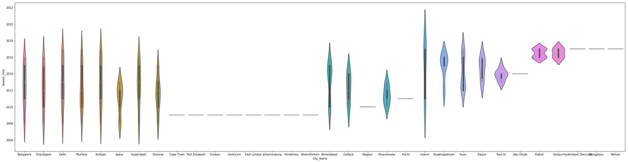

```python
plt.figure(figsize=(40,10))
sns.violinplot(x='City_Name', y='Season_Year', data=match
               )
plt.show()
```

```python
match.loc['2016-05-21':'2017-04-21']
```

| match_date | Match_SK | match_id | Team1 | Team2 | Season_Year | Venue_Name | City_Name | Country_Name | Toss_Winner | match_winner | Toss_Name | Win_Type | Outcome_Type | ManOfMach | Win_Margin | Country_id |
| --- | --- | --- | --- | --- | --- | --- | --- | --- | --- | --- | --- | --- | --- | --- | --- | --- |
| 2016-05-21 | 569 | 981010 | Rising Pune Supergiants | Kings XI Punjab | 2016 | Dr. Y.S. Rajasekhara Reddy ACA-VDCA Cricket St... | Visakhapatnam | India | Kings XI Punjab | Rising Pune Supergiants | bat | wickets | Result | MS Dhoni | 4.0 | 1 |
| 2016-05-21 | 570 | 981012 | Gujarat Lions | Mumbai Indians | 2016 | Green Park | Kanpur | India | Gujarat Lions | Gujarat Lions | field | wickets | Result | SK Raina | 6.0 | 1 |
| 2016-05-22 | 571 | 981014 | Kolkata Knight Riders | Sunrisers Hyderabad | 2016 | Eden Gardens | Kolkata | India | Sunrisers Hyderabad | Kolkata Knight Riders | field | runs | Result | YK Pathan | 22.0 | 1 |
| 2016-05-22 | 572 | 981016 | Delhi Daredevils | Royal Challengers Bangalore | 2016 | Shaheed Veer Narayan Singh International Stadium | Raipur | India | Royal Challengers Bangalore | Royal Challengers Bangalore | field | wickets | Result | V Kohli | 6.0 | 1 |
| 2016-05-24 | 573 | 981018 | Gujarat Lions | Royal Challengers Bangalore | 2016 | M Chinnaswamy Stadium | Bangalore | India | Royal Challengers Bangalore | Royal Challengers Bangalore | field | wickets | Result | AB de Villiers | 4.0 | 1 |
| 2016-05-25 | 574 | 981020 | Sunrisers Hyderabad | Kolkata Knight Riders | 2016 | Feroz Shah Kotla | Delhi | India | Kolkata Knight Riders | Sunrisers Hyderabad | field | runs | Result | MC Henriques | 22.0 | 1 |
| 2016-05-27 | 575 | 981022 | Gujarat Lions | Sunrisers Hyderabad | 2016 | Feroz Shah Kotla | Delhi | India | Sunrisers Hyderabad | Sunrisers Hyderabad | field | wickets | Result | DA Warner | 4.0 | 1 |
| 2016-05-29 | 576 | 981024 | Royal Challengers Bangalore | Sunrisers Hyderabad | 2016 | M Chinnaswamy Stadium | Bangalore | India | Sunrisers Hyderabad | Sunrisers Hyderabad | bat | runs | Result | BCJ Cutting | 8.0 | 1 |
| 2017-04-05 | 577 | 1082591 | Sunrisers Hyderabad | Royal Challengers Bangalore | 2017 | Rajiv Gandhi International Stadium Uppal | Hyderabad (Deccan) | India | Royal Challengers Bangalore | Sunrisers Hyderabad | Field | runs | Result | Yuvraj Singh | 35.0 | 1 |
| 2017-04-06 | 578 | 1082592 | Rising Pune Supergiants | Mumbai Indians | 2017 | Maharashtra Cricket Association Stadium | Pune | India | Rising Pune Supergiant | Rising Pune Supergiants | Field | wickets | Result | SPD Smith | 7.0 | 1 |
| 2017-04-07 | 579 | 1082593 | Gujarat Lions | Kolkata Knight Riders | 2017 | Saurashtra Cricket Association Stadium | Rajkot | India | Kolkata Knight Riders | Kolkata Knight Riders | Field | wickets | Result | CA Lynn | 10.0 | 1 |
| 2017-04-08 | 580 | 1082594 | Kings XI Punjab | Rising Pune Supergiants | 2017 | Holkar Cricket Stadium | Indore | India | Kings XI Punjab | Kings XI Punjab | Field | wickets | Result | GJ Maxwell | 6.0 | 1 |
| 2017-04-08 | 581 | 1082595 | Royal Challengers Bangalore | Delhi Daredevils | 2017 | M Chinnaswamy Stadium | Bengaluru | India | Royal Challengers Bangalore | Royal Challengers Bangalore | Bat | runs | Result | KM Jadhav | 15.0 | 1 |
| 2017-04-09 | 582 | 1082596 | Sunrisers Hyderabad | Gujarat Lions | 2017 | Rajiv Gandhi International Stadium Uppal | Hyderabad (Deccan) | India | Sunrisers Hyderabad | Sunrisers Hyderabad | Field | wickets | Result | Rashid Khan | 9.0 | 1 |
| 2017-04-09 | 583 | 1082597 | Mumbai Indians | Kolkata Knight Riders | 2017 | Wankhede Stadium | Mumbai | India | Mumbai Indians | Mumbai Indians | Field | wickets | Result | N Rana | 4.0 | 1 |
| 2017-04-10 | 584 | 1082598 | Kings XI Punjab | Royal Challengers Bangalore | 2017 | Holkar Cricket Stadium | Indore | India | Royal Challengers Bangalore | Kings XI Punjab | Bat | wickets | Result | AR Patel | 8.0 | 1 |
| 2017-04-11 | 585 | 1082599 | Rising Pune Supergiants | Delhi Daredevils | 2017 | Maharashtra Cricket Association Stadium | Pune | India | Rising Pune Supergiants | Delhi Daredevils | Field | runs | Result | SV Samson | 97.0 | 1 |
| 2017-04-12 | 586 | 1082600 | Mumbai Indians | Sunrisers Hyderabad | 2017 | Wankhede Stadium | Mumbai | India | Mumbai Indians | Mumbai Indians | Field | wickets | Result | JJ Bumrah | 4.0 | 1 |
| 2017-04-13 | 587 | 1082601 | Kolkata Knight Riders | Kings XI Punjab | 2017 | Eden Gardens | Kolkata | India | Kolkata Knight Riders | Kolkata Knight Riders | Field | wickets | Result | Narine | 8.0 | 1 |
| 2017-04-14 | 588 | 1082602 | Royal Challengers Bangalore | Mumbai Indians | 2017 | M Chinnaswamy Stadium | Bengaluru | India | Mumbai Indians | Mumbai Indians | Field | wickets | Result | KA Pollard | 4.0 | 1 |
| 2017-04-14 | 589 | 1082603 | Gujarat Lions | Rising Pune Supergiants | 2017 | Saurashtra Cricket Association Stadium | Rajkot | India | Gujarat Lions | Gujarat Lions | Field | wickets | Result | AJ Tye | 7.0 | 1 |
| 2017-04-15 | 590 | 1082604 | Kolkata Knight Riders | Sunrisers Hyderabad | 2017 | Eden Gardens | Kolkata | India | Sunrisers Hyderabad | Kolkata Knight Riders | Field | runs | Result | RV Uthappa | 17.0 | 1 |
| 2017-04-15 | 591 | 1082605 | Delhi Daredevils | Kings XI Punjab | 2017 | Feroz Shah Kotla | Delhi | India | Delhi Daredevils | Delhi Daredevils | Bat | runs | Result | CJ Anderson | 51.0 | 1 |
| 2017-04-16 | 592 | 1082606 | Mumbai Indians | Gujarat Lions | 2017 | Wankhede Stadium | Mumbai | India | Mumbai Indians | Mumbai Indians | Field | wickets | Result | N Rana | 6.0 | 1 |
| 2017-04-16 | 593 | 1082607 | Royal Challengers Bangalore | Rising Pune Supergiants | 2017 | M Chinnaswamy Stadium | Bengaluru | India | Royal Challengers Bangalore | Rising Pune Supergiants | Field | runs | Result | BA Stokes | 27.0 | 1 |
| 2017-04-17 | 594 | 1082608 | Delhi Daredevils | Kolkata Knight Riders | 2017 | Feroz Shah Kotla | Delhi | India | Delhi Daredevils | Kolkata Knight Riders | Bat | wickets | Result | NM Coulter-Nile | 4.0 | 1 |
| 2017-04-17 | 595 | 1082609 | Sunrisers Hyderabad | Kings XI Punjab | 2017 | Rajiv Gandhi International Stadium Uppal | Hyderabad (Deccan) | India | Kings XI Punjab | Sunrisers Hyderabad | Field | runs | Result | B Kumar | 5.0 | 1 |
| 2017-04-18 | 596 | 1082610 | Gujarat Lions | Royal Challengers Bangalore | 2017 | Saurashtra Cricket Association Stadium | Rajkot | India | Gujarat Lions | Royal Challengers Bangalore | Field | runs | Result | CH Gayle | 21.0 | 1 |
| 2017-04-19 | 597 | 1082611 | Sunrisers Hyderabad | Delhi Daredevils | 2017 | Rajiv Gandhi International Stadium Uppal | Hyderabad (Deccan) | India | Sunrisers Hyderabad | Sunrisers Hyderabad | Bat | runs | Result | KS Williamson | 15.0 | 1 |
| 2017-04-20 | 598 | 1082612 | Kings XI Punjab | Mumbai Indians | 2017 | Holkar Cricket Stadium | Indore | India | Mumbai Indians | Mumbai Indians | Field | wickets | Result | JC Buttler | 8.0 | 1 |
| 2017-04-21 | 599 | 1082613 | Kolkata Knight Riders | Gujarat Lions | 2017 | Eden Gardens | Kolkata | India | Gujarat Lions | Gujarat Lions | Field | wickets | Result | SK Raina | 4.0 | 1 |

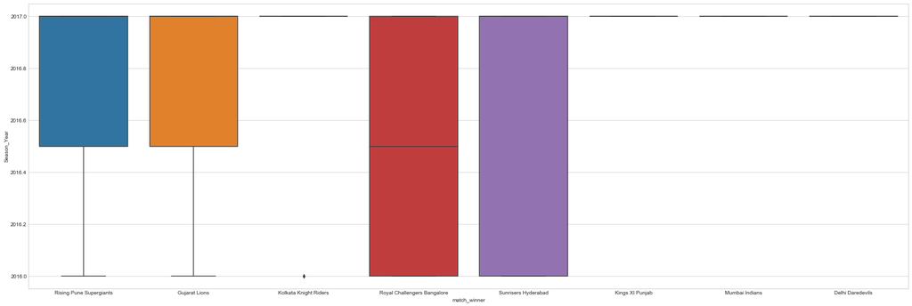

```python
plt.figure(figsize=(30,10))
sns.boxplot(x='match_winner', y='Season_Year', data=match.loc['2016-05-21':'2017-04-21']
               )
plt.show()
```

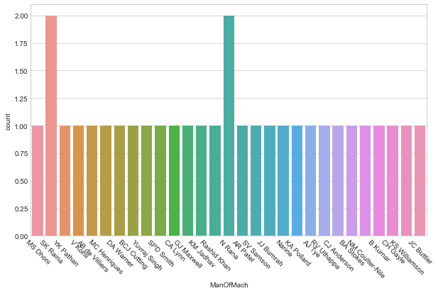

```python
plt.figure(figsize=(10,6))
# Count Plot (a.k.a. Bar Plot)
sns.countplot(x='ManOfMach', data=match.loc['2016-05-21':'2017-04-21'])

# Rotate x-labels
plt.xticks(rotation=-45)
```

Conclusion: This graph shows the count of the man of the match in the year 2016-17. It can be interpretted that SK Raina and N Rana have won the max man of the matches awards in the specified year. The range of the year can be changed according to your prefernece.

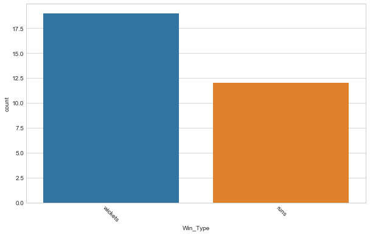

```python
plt.figure(figsize=(10,6))
# Count Plot (a.k.a. Bar Plot)
sns.countplot(x='Win_Type', data=match.loc['2016-05-21':'2017-04-21'])

# Rotate x-labels
plt.xticks(rotation=-45)
```

Conclusion: This graph shows the win type whether the matches are won by runs or by wickets. It can be concluded that the max win is by the number of wickets. The range of the year can be changed according to your requirements.

```python
match['match_winner'].head()
```

```
match_date
2008-04-18          Kolkata Knight Riders
2008-04-19            Chennai Super Kings
2008-04-19               Delhi Daredevils
2008-04-20    Royal Challengers Bangalore
2008-04-20          Kolkata Knight Riders
Name: match_winner, dtype: object
```

```python
match.head(5)
```

| match_date | Match_SK | match_id | Team1 | Team2 | Season_Year | Venue_Name | City_Name | Country_Name | Toss_Winner | match_winner | Toss_Name | Win_Type | Outcome_Type | ManOfMach | Win_Margin | Country_id |
| --- | --- | --- | --- | --- | --- | --- | --- | --- | --- | --- | --- | --- | --- | --- | --- | --- |
| 2008-04-18 | 0 | 335987 | Royal Challengers Bangalore | Kolkata Knight Riders | 2008 | M Chinnaswamy Stadium | Bangalore | India | Royal Challengers Bangalore | Kolkata Knight Riders | field | runs | Result | BB McCullum | 140.0 | 1 |
| 2008-04-19 | 1 | 335988 | Kings XI Punjab | Chennai Super Kings | 2008 | Punjab Cricket Association Stadium, Mohali | Chandigarh | India | Chennai Super Kings | Chennai Super Kings | bat | runs | Result | MEK Hussey | 33.0 | 1 |
| 2008-04-19 | 2 | 335989 | Delhi Daredevils | Rajasthan Royals | 2008 | Feroz Shah Kotla | Delhi | India | Rajasthan Royals | Delhi Daredevils | bat | wickets | Result | MF Maharoof | 9.0 | 1 |
| 2008-04-20 | 3 | 335990 | Mumbai Indians | Royal Challengers Bangalore | 2008 | Wankhede Stadium | Mumbai | India | Mumbai Indians | Royal Challengers Bangalore | bat | wickets | Result | MV Boucher | 5.0 | 1 |
| 2008-04-20 | 4 | 335991 | Kolkata Knight Riders | Deccan Chargers | 2008 | Eden Gardens | Kolkata | India | Deccan Chargers | Kolkata Knight Riders | bat | wickets | Result | DJ Hussey | 5.0 | 1 |

```python
winner_team_counts=match['match_winner'].value_counts()
winner_team_counts.head(20)
```

```
Mumbai Indians                 91
Chennai Super Kings            79
Kolkata Knight Riders          77
Royal Challengers Bangalore    73
Kings XI Punjab                70
Rajasthan Royals               63
Delhi Daredevils               62
Sunrisers Hyderabad            42
Deccan Chargers                29
Rising Pune Supergiants        15
Gujarat Lions                  13
Pune Warriors                  12
Kochi Tuskers Kerala            6
abandoned                       1
tied                            1
Name: match_winner, dtype: int64
```

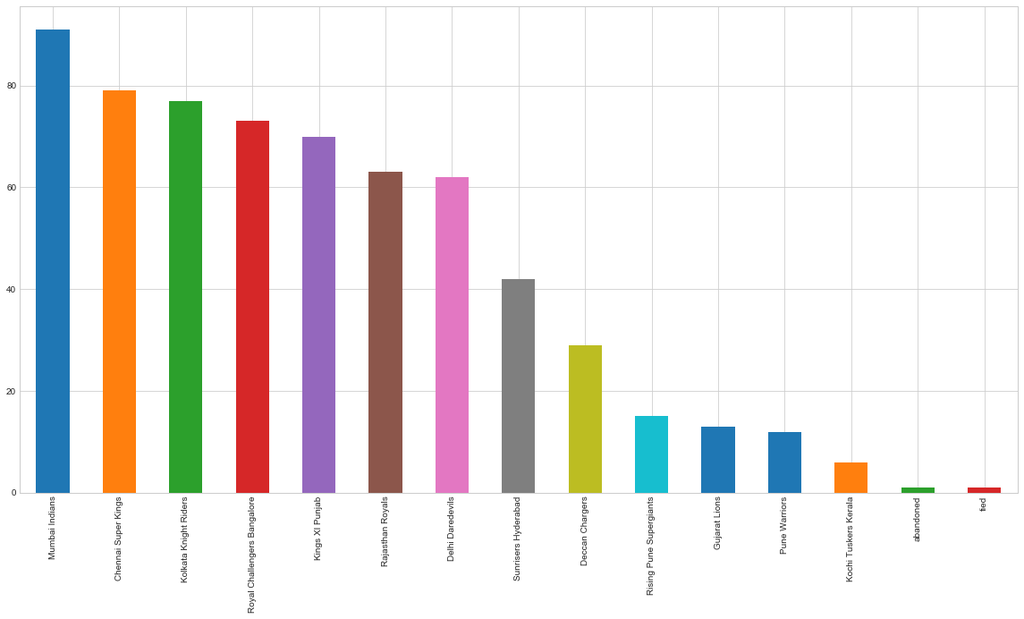

```python
winner_team_counts.plot(kind='bar',figsize=(20,10))
```

Conclusion: This graph shows that which team has won the max no of times. It can be seen here that MI has won the max no of times.

```python
match['City_Name'].head()
```

```
match_date
2008-04-18     Bangalore
2008-04-19    Chandigarh
2008-04-19         Delhi
2008-04-20        Mumbai
2008-04-20       Kolkata
Name: City_Name, dtype: object
```

```python
city_counts=match['City_Name'].value_counts()
city_counts.head(20)
```

```
Mumbai                85
Kolkata               61
Delhi                 60
Bangalore             58
Chennai               48
Chandigarh            42
Hyderabad             41
Jaipur                33
Pune                  32
Abu Dhabi             20
Durban                15
Centurion             12
Ahmedabad             12
Visakhapatnam         11
Rajkot                10
Dharamsala             9
Bengaluru              9
Johannesburg           8
Hyderabad (Deccan)     8
Cape Town              7
Name: City_Name, dtype: int64
```

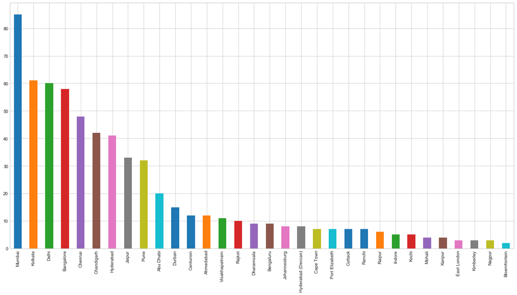

```python
city_counts.plot(kind='bar',figsize=(20,10))        #graph 11
```

Conclusion: This graph shows the cities which held the max no of matches in the ipl uptil 2017. It can be concluded that the max no of matches took place in Mumbai.